# Untitled

Mathis ARNAL

2023-11-22

# Un-comment and run line from 2 to 8 once

Installation de tous les packages requis

````r
# install.packages(" cowplot")
# install.packages("ade4")
# install.packages("FactoMineR")
# install.packages("stringr")
# install.packages("ggplot2")
# install.packages("ggrepel")
# install.packages("SensoMineR")
# ```

# With the `read.csv2()` function, import the orange data set and save it in an R object named orange.
# With the `summary()` function, make sure that the data set has been well imported.
# Check carefully the type of each variable.
# As there are 8 orange juices in the case study, set the `maxsum` argument to 8.
# Pay attention to the folder where is orange.csv
````

```r
orange <- read.csv2("C:/Users/mathi/OneDrive/Bureau/COURS STAT/COURS_PERCEPTION/orange.csv")
summary(orange, maxsum = 8)
```

```
##    Consumer            Juice               Liking           Nc
##  Length:848         Length:848         Min.   : 0.0   Min.   :1.000
##  Class :character   Class :character   1st Qu.: 4.0   1st Qu.:3.000
##  Mode  :character   Mode  :character   Median : 6.0   Median :3.000
##                                        Mean   : 5.4   Mean   :2.999
##                                        3rd Qu.: 7.0   3rd Qu.:3.000
##                                        Max.   :10.0   Max.   :5.000
##        Io              Su              Ac             Bt              Pu
##  Min.   :1.000   Min.   :1.000   Min.   :1.00   Min.   :1.000   Min.   :1.000
##  1st Qu.:2.000   1st Qu.:3.000   1st Qu.:3.00   1st Qu.:3.000   1st Qu.:2.000
##  Median :2.000   Median :3.000   Median :3.00   Median :3.000   Median :3.000
##  Mean   :2.192   Mean   :3.185   Mean   :3.15   Mean   :3.205   Mean   :2.654
##  3rd Qu.:3.000   3rd Qu.:4.000   3rd Qu.:4.00   3rd Qu.:4.000   3rd Qu.:3.000
##  Max.   :5.000   Max.   :5.000   Max.   :5.00   Max.   :5.000   Max.   :5.000
```

# With the `as.factor()` function, encode all the variables except the *Liking* as factors. With the `levels()` and the `nlevels()` functions, make sure that you have 106 consumers.

```r
for (j in c(1:2,4:9)) orange[,j] <- as.factor(orange[,j])
levels(orange$Consumer)
```

```
##   [1] "j1"   "j10"  "j100" "j101" "j102" "j103" "j104" "j105" "j106" "j11"
##  [11] "j12"  "j13"  "j14"  "j15"  "j16"  "j17"  "j18"  "j19"  "j2"   "j20"
##  [21] "j21"  "j22"  "j23"  "j24"  "j25"  "j26"  "j27"  "j28"  "j29"  "j3"
##  [31] "j30"  "j31"  "j32"  "j33"  "j34"  "j35"  "j36"  "j37"  "j38"  "j39"
##  [41] "j4"   "j40"  "j41"  "j42"  "j43"  "j44"  "j45"  "j46"  "j47"  "j48"
##  [51] "j49"  "j5"   "j50"  "j51"  "j52"  "j53"  "j54"  "j55"  "j56"  "j57"
##  [61] "j58"  "j59"  "j6"   "j60"  "j61"  "j62"  "j63"  "j64"  "j65"  "j66"
##  [71] "j67"  "j68"  "j69"  "j7"   "j70"  "j71"  "j72"  "j73"  "j74"  "j75"
##  [81] "j76"  "j77"  "j78"  "j79"  "j8"   "j80"  "j81"  "j82"  "j83"  "j84"
##  [91] "j85"  "j86"  "j87"  "j88"  "j89"  "j9"   "j90"  "j91"  "j92"  "j93"
## [101] "j94"  "j95"  "j96"  "j97"  "j98"  "j99"
```

```r
nlevels(orange$Consumer)
```

```
## [1] 106
```

# Visualization of the data distribution.

# https://r-charts.com/colors/

```r
table(orange[,5])
```

```
##
##   1   2   3   4   5
## 197 351 247  46   7
```

```r
tab <- as.data.frame(table(orange[,5]))
```

Répartition des notes

# 1st attempt

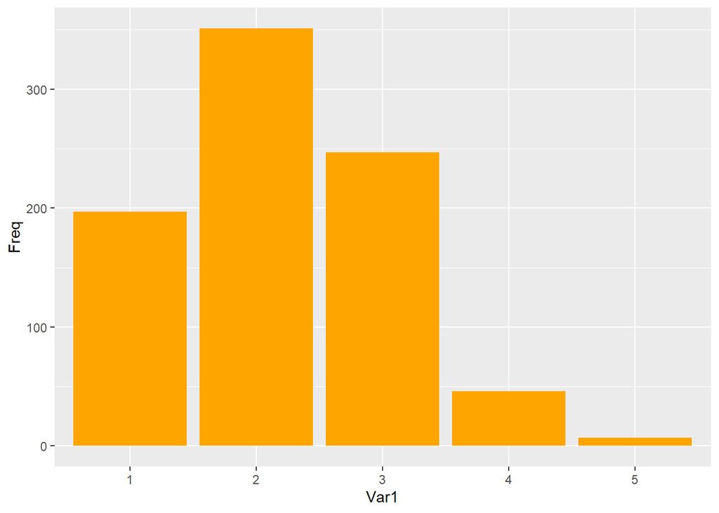

```r
library(ggplot2)
ggplot(tab, aes(x = Var1, y = Freq)) +
  geom_bar(stat = "identity", fill = "orange")
```

# 2nd attempt

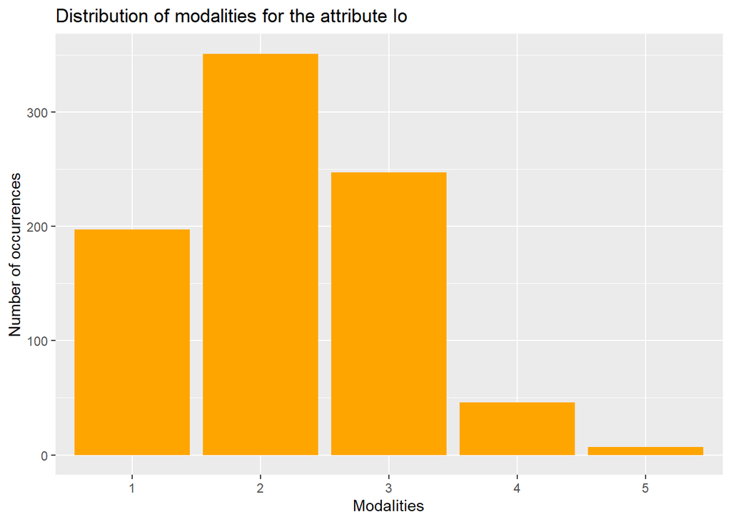

```r
ggplot(tab, aes(x = Var1, y = Freq)) +
  geom_bar(stat = "identity", fill = "orange") +
  xlab("Modalities") +
  ylab("Number of occurrences") +
  ggtitle("Distribution of modalities for the attribute Io")
```

# 3rd attempt

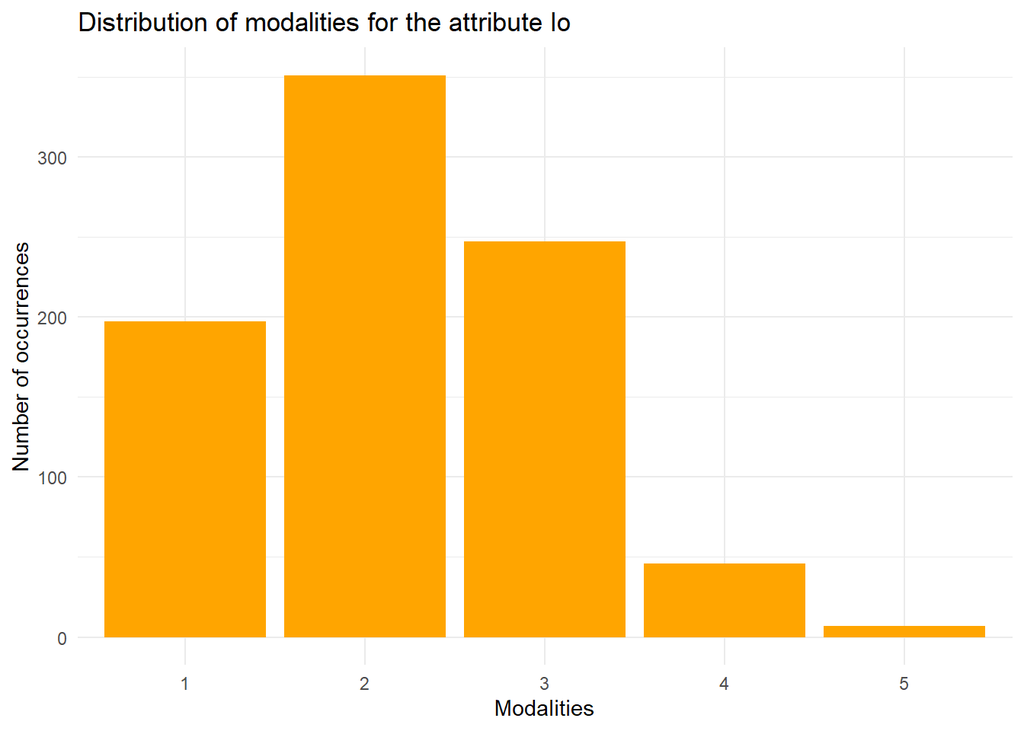

```r
ggplot(tab, aes(x = Var1, y = Freq)) +
  geom_bar(stat = "identity", fill = "orange") +
  xlab("Modalities") +
  ylab("Number of occurrences") +
  ggtitle("Distribution of modalities for the attribute Io") +
  theme_minimal()
```

Belle représentation des modalités

# The same type of visualization can be obtained by product.

```r
table(orange[,2],orange[,5])
```

```
##
##         1  2  3  4  5
##   1JPA 29 42 30  5  0
##   2JPR 22 44 34  5  1
##   3JWA 26 44 33  3  0
##   4JWR 22 39 35  9  1
##   5TPA 26 50 20  7  3
##   6TPR 21 45 32  8  0
##   7TWA 27 44 29  4  2
##   8TWR 24 43 34  5  0
```

```r
tab <- as.data.frame(table(orange[,2],orange[,5]))
```

Répartition des notes par produit

# 1st attempt

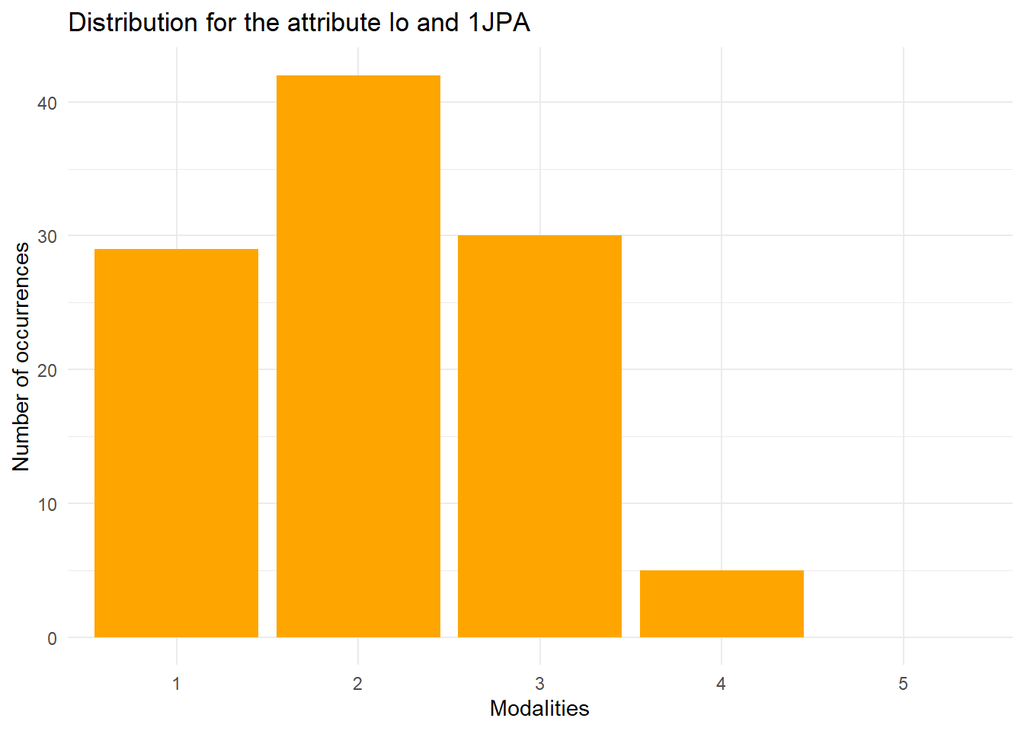

```r
JPA <- ggplot(tab[tab$Var1 == "1JPA",], aes(x = Var2, y = Freq)) +
  geom_bar(stat = "identity", fill = "orange") +
  xlab("Modalities") +
  ylab("Number of occurrences") +
  ggtitle("Distribution for the attribute Io and 1JPA") +
  theme_minimal()

JPA
```

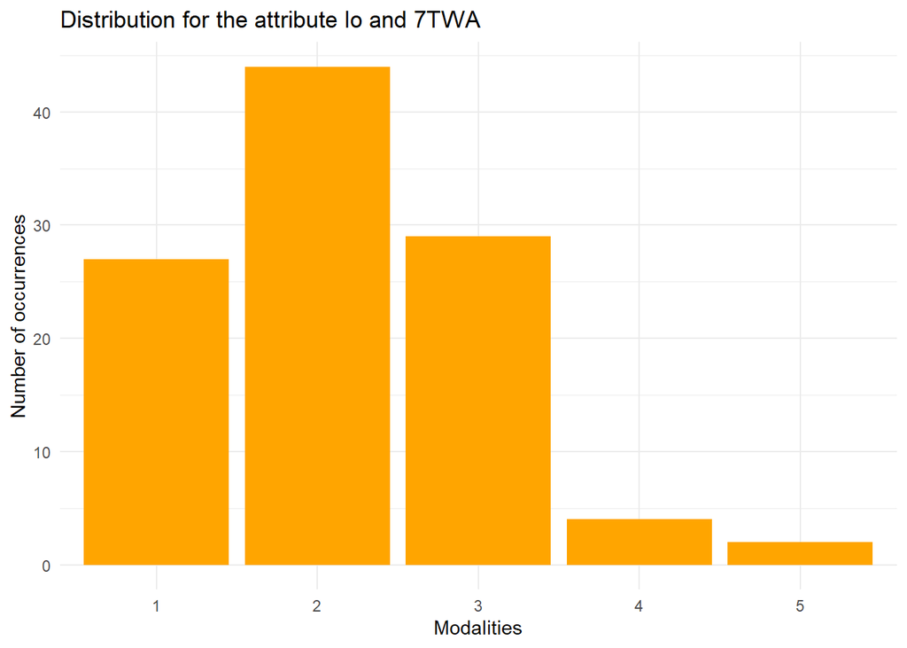

```r
TWA <- ggplot(tab[tab$Var1 == "7TWA",], aes(x = Var2, y = Freq)) +
  geom_bar(stat = "identity", fill = "orange") +
  xlab("Modalities") +
  ylab("Number of occurrences") +
  ggtitle("Distribution for the attribute Io and 7TWA") +
  theme_minimal()

TWA
```

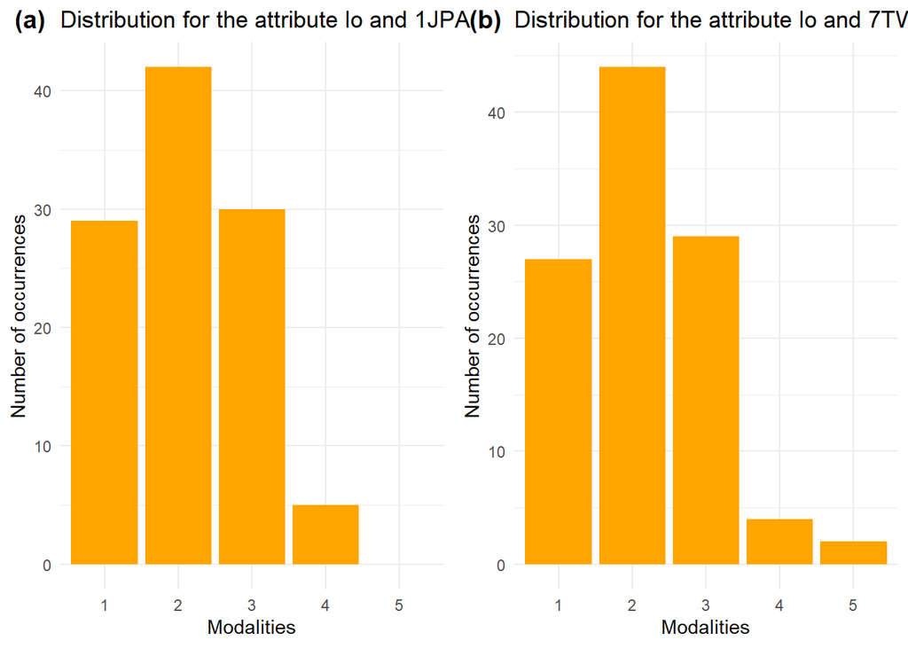

```r
library(cowplot)
plot_grid(JPA, TWA, labels=c("(a)", "(b)"), ncol = 2, nrow = 1)
```

# 2nd attempt

```r
tab[tab$Var1 == "1JPA"|tab$Var1 == "7TWA",]
```

```
##    Var1 Var2 Freq
## 1  1JPA    1   29
## 7  7TWA    1   27
## 9  1JPA    2   42
## 15 7TWA    2   44
## 17 1JPA    3   30
## 23 7TWA    3   29
## 25 1JPA    4    5
## 31 7TWA    4    4
## 33 1JPA    5    0
## 39 7TWA    5    2
```

```r
max(tab[tab$Var1 == "1JPA"|tab$Var1 == "7TWA",]$Freq)
```

```
## [1] 44
```

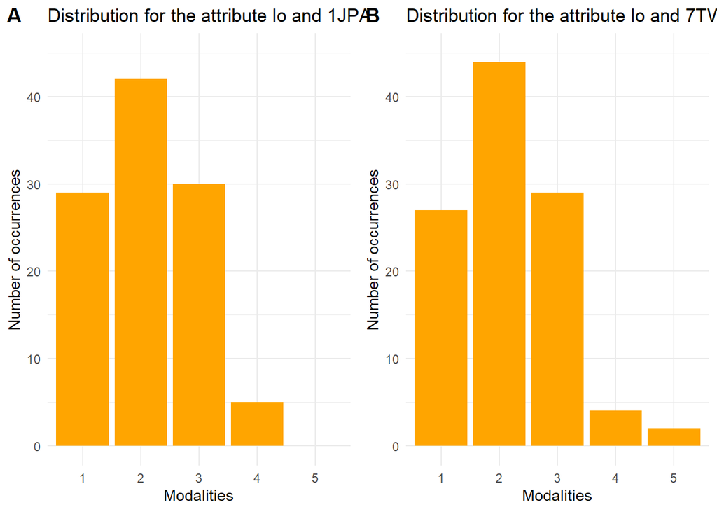

```r
JPA <- ggplot(tab[tab$Var1 == "1JPA",], aes(x = Var2, y = Freq)) +
  geom_bar(stat = "identity", fill = "orange") +
  xlab("Modalities") +
  ylab("Number of occurrences") +
  ylim(0, 45) +
  ggtitle("Distribution for the attribute Io and 1JPA") +
  theme_minimal()

TWA <- ggplot(tab[tab$Var1 == "7TWA",], aes(x = Var2, y = Freq)) +
  geom_bar(stat = "identity", fill = "orange") +
  xlab("Modalities") +
  ylab("Number of occurrences") +
  ylim(0, 45) +
  ggtitle("Distribution for the attribute Io and 7TWA") +
  theme_minimal()

plot_grid(JPA, TWA, labels = c("A","B"), ncol = 2, nrow = 1)
```

Comparaision de la répartition de la modalité pour 2 produits différents (JPA ET 7TWA)

# Aggregate the categories 1 and 2 into ne for not enough, 4 and 5 into tm for too much,

# and finally recode the category 3 into JAR.

```r
for (j in 4:9) levels(orange[,j]) <- c("ne","ne","JAR","tm","tm")
```

On recode en mode JAR -> on passe de 5 à 3 modalités

# Recoding of the variables with the `acm.disjonctif()` function.

```r
library(ade4)
orange.dummy <- acm.disjonctif(orange[,4:9])
orange.dummy[1:5,]
```

```
##   Nc.ne Nc.JAR Nc.tm Io.ne Io.JAR Io.tm Su.ne Su.JAR Su.tm Ac.ne Ac.JAR Ac.tm
## 1     1      0     0     0      1     0     0      0     1     1      0     0
## 2     0      1     0     0      1     0     0      0     1     1      0     0
## 3     1      0     0     0      1     0     0      0     1     1      0     0
## 4     1      0     0     1      0     0     0      0     1     0      1     0
## 5     0      1     0     0      1     0     0      0     1     1      0     0
##   Bt.ne Bt.JAR Bt.tm Pu.ne Pu.JAR Pu.tm
## 1     0      1     0     0      1     0
## 2     0      1     0     0      1     0
## 3     1      0     0     1      0     0
## 4     1      0     0     1      0     0
## 5     0      1     0     0      1     0
```

On crée le tableau disjonctif complet

# Creation of an R object containing the information about the consumers,

# the products and the dummy variables.

```r
orange.dummy <- cbind(orange[,1:3], orange.dummy)
orange.dummy[1:5,]
```

```
##   Consumer Juice Liking Nc.ne Nc.JAR Nc.tm Io.ne Io.JAR Io.tm Su.ne Su.JAR
## 1       j1  1JPA      7     1      0     0     0      1     0     0      0
## 2       j1  2JPR      6     0      1     0     0      1     0     0      0
## 3       j1  3JWA      5     1      0     0     0      1     0     0      0
## 4       j1  4JWR      4     1      0     0     1      0     0     0      0
## 5       j1  5TPA      6     0      1     0     0      1     0     0      0
##   Su.tm Ac.ne Ac.JAR Ac.tm Bt.ne Bt.JAR Bt.tm Pu.ne Pu.JAR Pu.tm
## 1     1     1      0     0     0      1     0     0      1     0
## 2     1     1      0     0     0      1     0     0      1     0
## 3     1     1      0     0     1      0     0     1      0     0
## 4     1     0      1     0     1      0     0     1      0     0
## 5     1     1      0     0     0      1     0     0      1     0
```

On ajoute au tableau disjonctif complet les variables Produit et Juge.

# Use the AovSum() function of the FactoMineR package to estimate your model for which the liking is explained by

# the presence or absence of the defects, the consumers and the products.

```r
library(FactoMineR)
res.penalty.all <- AovSum(Liking ~ Nc.ne + Nc.tm + Io.ne + Io.tm + Su.ne + Su.tm +
                            Ac.ne + Ac.tm + Bt.ne + Bt.tm + Pu.ne + Pu.tm +
                            Consumer + Juice, data = orange.dummy)
names(res.penalty.all)
```

```
## [1] "Ftest" "Ttest"
```

```r
res.penalty.all$Ttest
```

```
##                      Estimate Std. Error       t value      Pr(>|t|)
## (Intercept)      8.3926829420  0.1337639  62.742515602 9.514868e-295
## Nc.ne           -0.5890063346  0.1284073  -4.587014383  5.299026e-06
## Nc.tm           -0.2989275234  0.1274688  -2.345102695  1.929134e-02
## Io.ne           -0.5269586351  0.1112576  -4.736384698  2.619144e-06
## Io.tm           -0.5162067981  0.2093083  -2.466250967  1.388452e-02
## Su.ne           -1.5160773651  0.1322444 -11.464209132  4.500635e-28
## Su.tm           -1.2005414426  0.1157576 -10.371170715  1.373383e-23
## Ac.ne           -1.1147723967  0.1323695  -8.421670306  1.991188e-16
## Ac.tm           -0.9592147717  0.1143617  -8.387555066  2.594846e-16
## Bt.ne           -1.0501313483  0.1550522  -6.772762090  2.618223e-11
## Bt.tm           -1.1998402063  0.1122184 -10.692009094  7.149965e-25
## Pu.ne           -0.8020263116  0.1464931  -5.474838802  6.044901e-08
## Pu.tm           -0.8162542747  0.1498453  -5.447313384  7.015540e-08
## Consumer - j1    0.5543733210  0.4508726   1.229556447  2.192632e-01
## Consumer - j10  -0.1528473178  0.4428028  -0.345181429  7.300584e-01
## Consumer - j100 -0.8988101677  0.4459773  -2.015371988  4.423527e-02
## Consumer - j101  0.6472378955  0.4489338   1.441722212  1.498137e-01
## Consumer - j102 -1.1403922905  0.4428642  -2.575038537  1.022057e-02
## Consumer - j103 -1.1281065767  0.4510892  -2.500850168  1.260974e-02
## Consumer - j104  0.2100832266  0.4604321   0.456274023  6.483300e-01
## Consumer - j105 -0.4726573669  0.4507117  -1.048691178  2.946707e-01
## Consumer - j106  0.0867434431  0.4488920   0.193238986  8.468261e-01
## Consumer - j11  -0.1622490174  0.4413563  -0.367614608  7.132682e-01
## Consumer - j12  -0.6576961948  0.4469073  -1.471661279  1.415475e-01
## Consumer - j13   1.0840618334  0.4412962   2.456540083  1.426222e-02
## Consumer - j14   0.0979923582  0.4398405   0.222790662  8.237614e-01
## Consumer - j15   0.2060179892  0.4421665   0.465928542  6.414070e-01
## Consumer - j16   1.0613431680  0.4482510   2.367742899  1.815921e-02
## Consumer - j17   0.9439173836  0.4420000   2.135559760  3.305071e-02
## Consumer - j18   0.0498814929  0.4418680   0.112887778  9.101509e-01
## Consumer - j19  -1.9677864219  0.4485776  -4.386725032  1.321914e-05
## Consumer - j2   -0.2238346510  0.4548657  -0.492089577  6.228054e-01
## Consumer - j20   0.2896305294  0.4436506   0.652834731  5.140704e-01
## Consumer - j21   0.1475399393  0.4467852   0.330225693  7.413251e-01
## Consumer - j22  -0.1096417743  0.4537544  -0.241632401  8.091335e-01
## Consumer - j23   0.2611868741  0.4518882   0.577990014  5.634508e-01
## Consumer - j24   0.9907956677  0.4424275   2.239453325  2.542970e-02
## Consumer - j25  -1.1381452892  0.4486786  -2.536660729  1.140075e-02
## Consumer - j26   0.2743681294  0.4501970   0.609440162  5.424242e-01
```

[output cut: 73 more lines]

```
## Consumer - j93   0.1159040306  0.4428119   0.261745512  7.935922e-01
## Consumer - j94   1.3481657278  0.4550008   2.962996291  3.146613e-03
## Consumer - j95   0.4075019836  0.4418039   0.922359341  3.566489e-01
## Consumer - j96  -1.1312828475  0.4431625  -2.552749567  1.089198e-02
## Consumer - j97   0.3662555407  0.4445275   0.823921071  4.102561e-01
## Consumer - j98  -1.1142266233  0.4518499  -2.465922105  1.389716e-02
## Consumer - j99  -0.2267763310  0.4477826  -0.506442916  6.127002e-01
## Juice - 1JPA     0.2670658138  0.1247228   2.141275855  3.258548e-02
## Juice - 2JPR    -0.0508857406  0.1251271  -0.406672436  6.843689e-01
## Juice - 3JWA     0.0062558732  0.1274275   0.049093578  9.608583e-01
## Juice - 4JWR    -0.2752265816  0.1292075  -2.130113809  3.349925e-02
## Juice - 5TPA    -0.2130884700  0.1218954  -1.748124911  8.086685e-02
## Juice - 6TPR     0.0210890346  0.1457560   0.144687220  8.849982e-01
## Juice - 7TWA     0.1023349967  0.1306958   0.783001679  4.338825e-01
## Juice - 8TWR     0.1424550739  0.1238684   1.150051633  2.505029e-01
```

On introduit dans le modèle uniquement les pénalités (les modalités JAR de chaque variable ne sont pas dans le modèle) On remarque que le coefficient associé aux différentes pénalités sont bien tous négatifs. Ils baissent donc bien la valeur hédonique. Certaines pénalités sont plus fortes que d’autres.

# More easily with the `JAR()` function.

```r
library(SensoMineR)
res.jar <- JAR(orange, col.p = 2, col.j = 1, col.pref = 3, jarlevel="JAR")
res.jar$penalty2
```

```
##    Multidimensional penalty (all products) Std. Error     Pr(>|t|)
## ne                              -0.5890063  0.1284073 5.299026e-06
## tm                              -0.2989275  0.1274688 1.929134e-02
## ne                              -0.5269586  0.1112576 2.619144e-06
## tm                              -0.5162068  0.2093083 1.388452e-02
## ne                              -1.5160774  0.1322444 4.500635e-28
## tm                              -1.2005414  0.1157576 1.373383e-23
## ne                              -1.1147724  0.1323695 1.991188e-16
## tm                              -0.9592148  0.1143617 2.594846e-16
## ne                              -1.0501313  0.1550522 2.618223e-11
## tm                              -1.1998402  0.1122184 7.149965e-25
## ne                              -0.8020263  0.1464931 6.044901e-08
## tm                              -0.8162543  0.1498453 7.015540e-08
```

La fonction JAR réalise tout à la fois .A partir du tableau initial, il crée le tableau disjonctif complet, passes les modalités sous forme JAR. Il prend comme argument la position de la variable produit “col.p, la position de la variable juge”col.j” et la variable de préférence (ici le Liking) “col.pref”. Et réalise l’analyse de variance.

# Focus on one product.

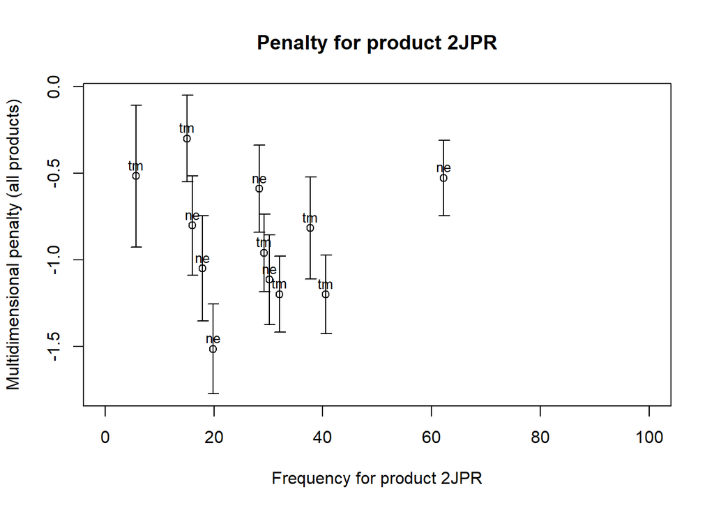

```r
plot.JAR(res.jar, name.prod = "2JPR", model = 2)
```

On s’intéresse ici à un produit, on est donc dans l’espace produit pour la fréquence.

Selon le produit, on va donc avoir les coordonées en ordonnée qui reste les mêmes (défini dans l’espace de tous les produits), mais la fréquence ,elle, est inhérente à chaque produit. Ce qui va bouger selon le produit sera juste les fréquences des pénalités, donc uniquement sur l’axe des abcisses. En pratique, c’est le nombre de citations d’un produit à l’autre qui n’est pas la même, mais la pénalité en ordonnée est défini sur tous les produit).

Notre objectif global est d’dentifier le graphique qui va nous permettre de régler le défaut prioritaire. Ici, on a pas les variables associés aux modalité aux ne et tm, donc on va faire ça par la suite

# The graphical output is not informative when the levels of the sensory attributes are the same.

# Consequently, they are changed with the paste() function,

# to add the name of the attribute in front of its levels.

```r
j<- 5
colnames(orange)[j]
```

```
## [1] "Io"
```

```r
levels(orange[,j])[1]
```

```
## [1] "ne"
```

```r
paste(colnames(orange)[j], levels(orange[,j])[1], sep=".")
```

```
## [1] "Io.ne"
```

```r
for (j in 4:9) levels(orange[,j]) <- c(paste(colnames(orange)[j], levels(orange[,j])[1], sep="."),"JAR",
                                       paste(colnames(orange)[j], levels(orange[,j])[3], sep="."))
summary(orange)
```

```
##     Consumer       Juice         Liking         Nc          Io          Su
##  j1     :  8   1JPA   :106   Min.   : 0.0   Nc.ne:187   Io.ne:548   Su.ne:189
##  j10    :  8   2JPR   :106   1st Qu.: 4.0   JAR  :475   JAR  :247   JAR  :356
##  j100   :  8   3JWA   :106   Median : 6.0   Nc.tm:186   Io.tm: 53   Su.tm:303
##  j101   :  8   4JWR   :106   Mean   : 5.4
##  j102   :  8   5TPA   :106   3rd Qu.: 7.0
##  j103   :  8   6TPR   :106   Max.   :10.0
##  (Other):800   (Other):212
##      Ac          Bt          Pu
##  Ac.ne:198   Bt.ne:122   Pu.ne:377
##  JAR  :349   JAR  :452   JAR  :303
##  Ac.tm:301   Bt.tm:274   Pu.tm:168
##
##
##
##
```

# JAR function.

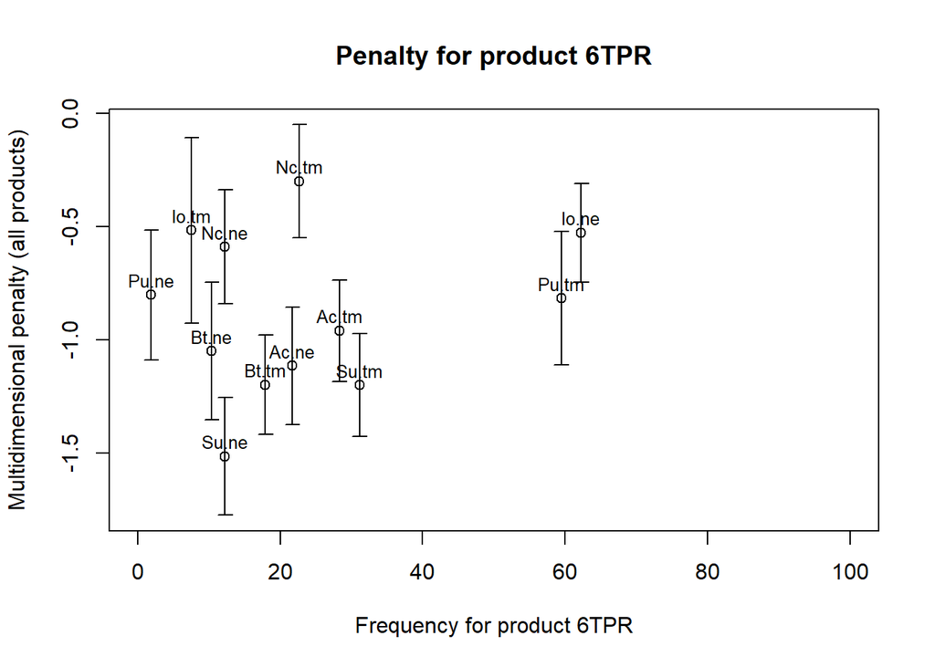

```r
res.jar <- JAR(orange, col.p = 2, col.j = 1, col.pref = 3, jarlevel="JAR")
plot.JAR(res.jar, name.prod = "6TPR", model = 2)
```

On a désormais un graphique avec chaque penalité le nom les variables et la modalité associé Description: On a deux défaut (Pu.tm et Io.ne) qui sont très fréquents dans ce produit et qui résultent en une pénalité modérée (-0.5) . On a un autre défaut (Su.ne) qui est bien moins fréquents mais qui est associé à une forte pénalité (-1.5) => A nous de choisir quel défaut on veut gérer pour ce produit.

Ici, la pénalité est déterminé dans l’espace de tous les produits. Or, on aimerait également la pénalité d’une modalité sur un produit en particulier, et pouvoir la comparer à la pénalité pour tous les produits.

# Penalties can also be estimated for each product.

```r
orange.dummy.2JPR <- orange.dummy[orange.dummy$Juice == "2JPR",]
```

C’est un choix de regarder les pénalités pour un produit donné où sur l’ensemble des produits.

# Use the AovSum() function to estimate your model for which the liking is explained by the presence or absence of the defects.

```r
res.penalty.one <- AovSum(Liking ~ Nc.ne + Nc.tm + Io.ne + Io.tm + Su.ne + Su.tm +
                            Ac.ne + Ac.tm + Bt.ne + Bt.tm + Pu.ne + Pu.tm,
                          data = orange.dummy.2JPR)
res.penalty.one$Ttest
```

```
##                Estimate Std. Error    t value     Pr(>|t|)
## (Intercept)  8.49817064  0.4400732 19.3108136 2.644038e-34
## Nc.ne       -0.70038572  0.3711512 -1.8870630 6.227093e-02
## Nc.tm       -0.41950117  0.4700152 -0.8925269 3.744142e-01
## Io.ne       -0.60754890  0.3485069 -1.7432906 8.458775e-02
## Io.tm        0.14837924  0.7127726  0.2081719 8.355499e-01
## Su.ne       -1.95313327  0.4674866 -4.1779447 6.634069e-05
## Su.tm       -1.35079614  0.3635888 -3.7151749 3.463738e-04
## Ac.ne       -0.79461476  0.3966985 -2.0030696 4.808076e-02
## Ac.tm       -0.05244214  0.3931076 -0.1334040 8.941621e-01
## Bt.ne       -1.02209736  0.4518992 -2.2617818 2.604043e-02
## Bt.tm       -1.91732893  0.3716827 -5.1585106 1.400798e-06
## Pu.ne       -0.86253187  0.4656811 -1.8521943 6.717015e-02
## Pu.tm       -1.01122646  0.3564502 -2.8369359 5.590639e-03
```

On refait une anlyse de la variance mais sur le tableau disjonctif concernant uniquement le produit 2JPR.

#They can be compared.

```r
penalties <- cbind(res.jar$penalty2, res.penalty.one$Ttest[-1,])[,c(1,4)]
penalties <- as.data.frame(penalties)
colnames(penalties) <- c("All_products","JPR")
```

# https://ggplot2.tidyverse.org/reference/geom_point.html

On crée une table avec les pénalités calculées avec l’analyse de la variance sur l’espace produit et pour un produit (2JPR)

# 1st attempt

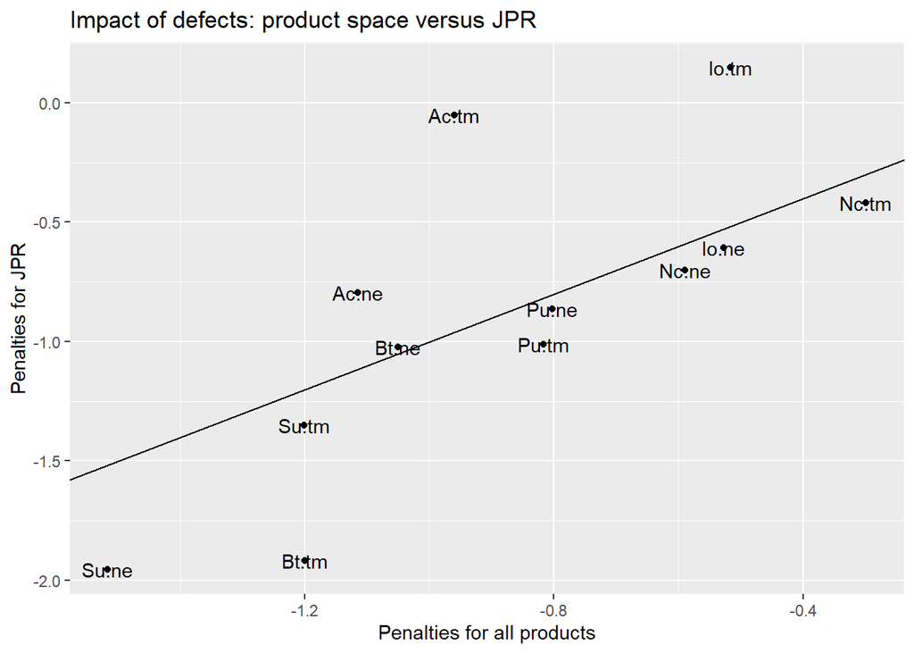

```r
ggplot(penalties, aes(x = All_products, y = JPR)) +
  geom_point() +
  geom_text(label = rownames(penalties)) +
  geom_abline(intercept = 0, slope = 1) +
  xlab("Penalties for all products") +
  ylab("Penalties for JPR") +
  ggtitle("Impact of defects: product space versus JPR")
```

Le plot actuel n’est pas orthonormé, donc on va ajouter ” coord_fixed()“.

# The coord_fixed function is very useful in case you want a

# fixed aspect ratio for your plot regardless the size of the plotting device,

# this is, one unit along the X axis will be the same unit along the Y axis.

# https://ggplot2.tidyverse.org/reference/coord_fixed.html

# 2nd attempt

# For min and max for ggplot.

```r
summary(penalties)
```

```
##   All_products          JPR
##  Min.   :-1.5161   Min.   :-1.9531
##  1st Qu.:-1.1360   1st Qu.:-1.1043
##  Median :-0.8877   Median :-0.8286
##  Mean   :-0.8825   Mean   :-0.8786
##  3rd Qu.:-0.5735   3rd Qu.:-0.5605
##  Max.   :-0.2989   Max.   : 0.1484
```

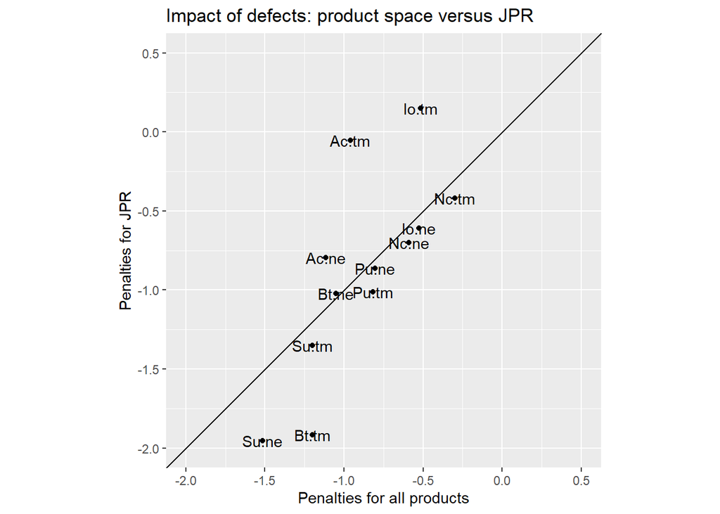

```r
ggplot(penalties, aes(x = All_products, y = JPR)) +
  geom_point() +
  geom_text(label = rownames(penalties)) +
  geom_abline(intercept = 0, slope = 1) +
  xlab("Penalties for all products") +
  ylab("Penalties for JPR") +
  ggtitle("Impact of defects: product space versus JPR") +
  coord_fixed() +
  ylim(-2,0.5) +
  xlim(-2,0.5)
```

On rajoute ggrepel pour plus de lisibilité des labels.

# https://ggrepel.slowkow.com/index.html

# https://ggrepel.slowkow.com/reference/geom_text_repel.html

# attempt ggrepel

```r
library(ggrepel)
```

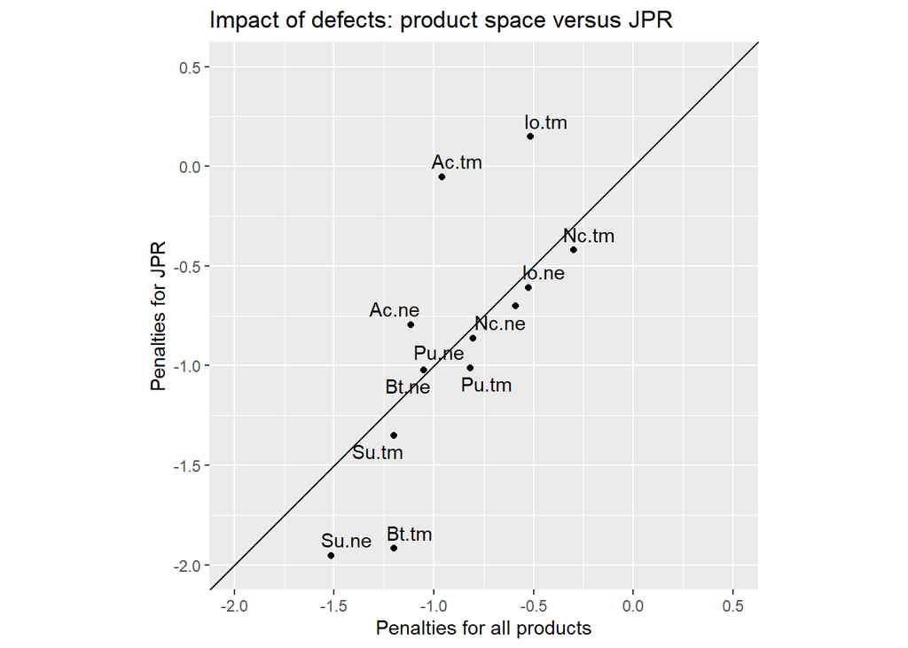

```r
ggplot(penalties, aes(x = All_products, y = JPR)) +
  geom_point() +
  geom_text_repel(label = rownames(penalties)) +
  geom_abline(intercept = 0, slope = 1) +
  xlab("Penalties for all products") +
  ylab("Penalties for JPR") +
  ggtitle("Impact of defects: product space versus JPR") +
  coord_fixed() +
  ylim(-2,0.5) +
  xlim(-2,0.5)
```

On rajoute un thème

# https://ggplot2-book.org/polishing.html

# attempt theme

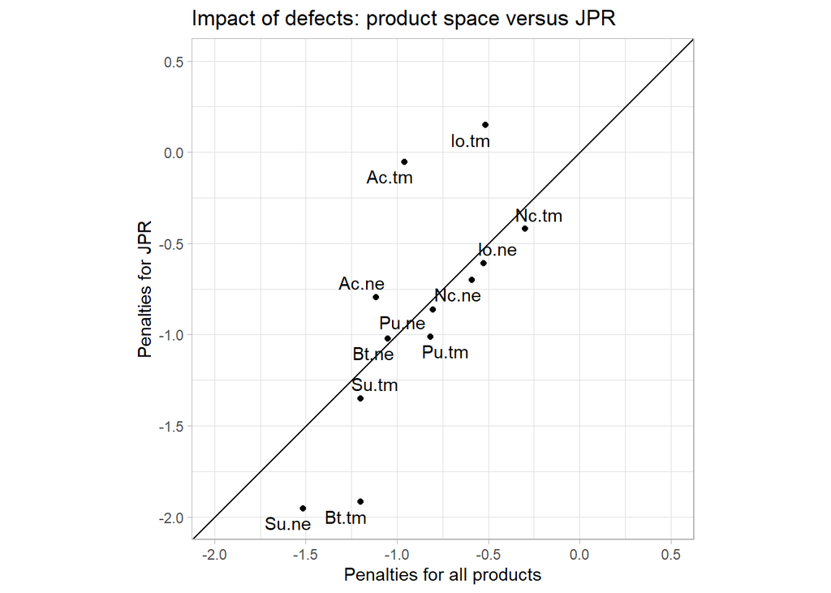

```r
ggplot(penalties, aes(x = All_products, y = JPR)) +
  geom_point() +
  geom_text_repel(label = rownames(penalties)) +
  geom_abline(intercept = 0, slope = 1) +
  xlab("Penalties for all products") +
  ylab("Penalties for JPR") +
  ggtitle("Impact of defects: product space versus JPR") +
  coord_fixed() +
  ylim(-2,0.5) +
  xlim(-2,0.5) +
  theme_light()
```

On a en abcisse la pénalité pour tous les produits, et en ordonnée la pénalité pour le produit JPR. Si on a une pénalité au dessus de la droite, alors la pénalité pour le produit JPR est plus grande que pour la moyenne des produits. ça a tendance à moins affecter négativement la note du produit(Ac.tm et Io.tm). De manière similaire, Si on a une pénalité en dessous de la courbe, c’est une pénalité qui affecte plus le produit JPR que la moyenne des produits (Su.ne et Bt.tm)

# Running a Multiple Correspondence Analysis

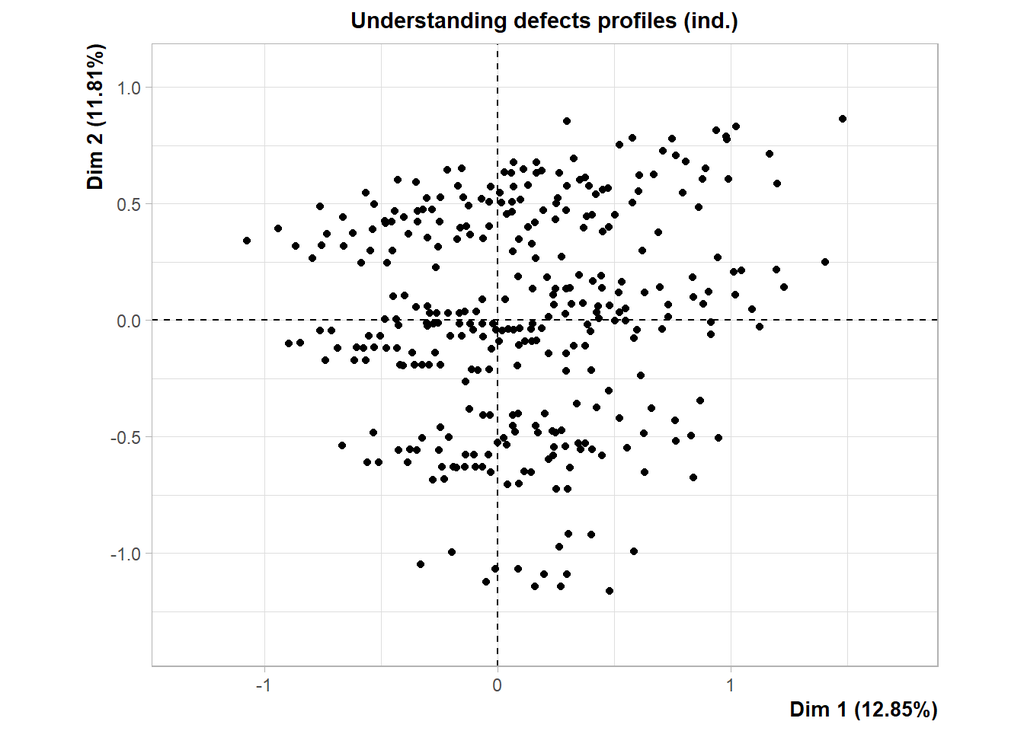

```r
res.mca <- MCA(orange, quanti.sup = 3, quali.sup = 1:2, graph = F)
plot.MCA(res.mca, invisible = c("var","quali.sup"), label = "none", title = "Understanding defects profiles (ind.)")
```

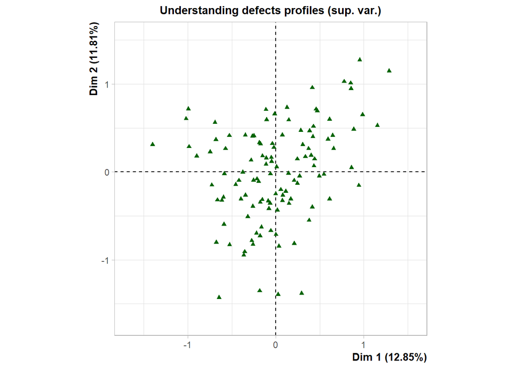

```r
plot.MCA(res.mca, invisible = c("ind","var"), label = "none", title = "Understanding defects profiles (sup. var.)")
```

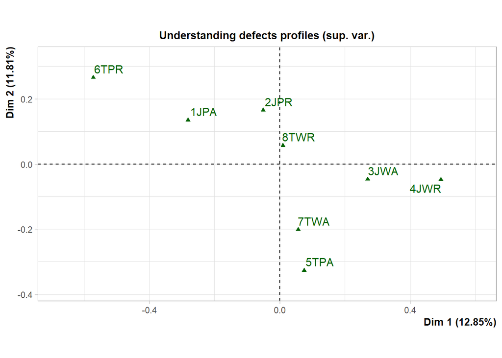

```r
res.mca <- MCA(orange[,-1], quanti.sup = 2, quali.sup = 1, graph = F)
plot.MCA(res.mca, invisible = c("ind","var"), title = "Understanding defects profiles (sup. var.)")
```

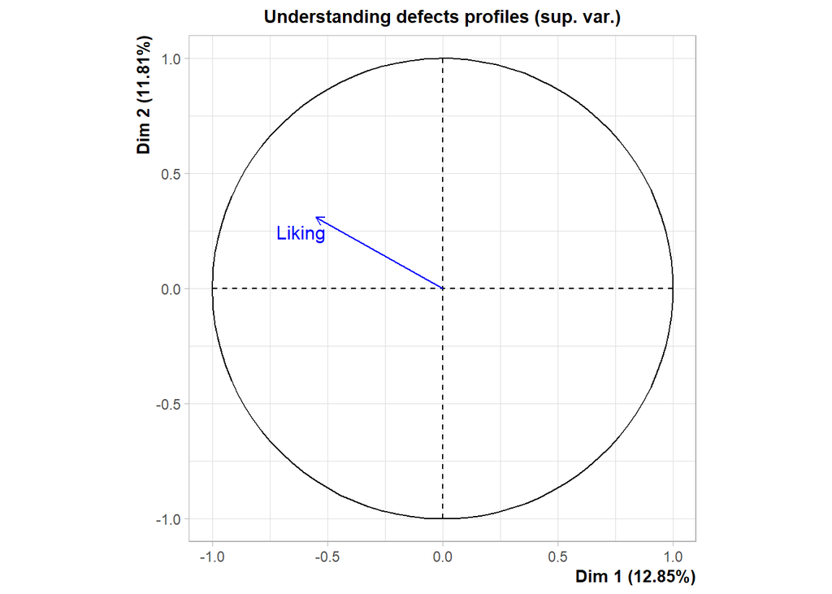

```r
plot.MCA(res.mca, choix = "quanti.sup", title = "Understanding defects profiles (sup. var.)")
```

L’ACM nous permet d’identifier les produits qui sont les plus apprécié (Ceux qui sont selon le gradient liking)

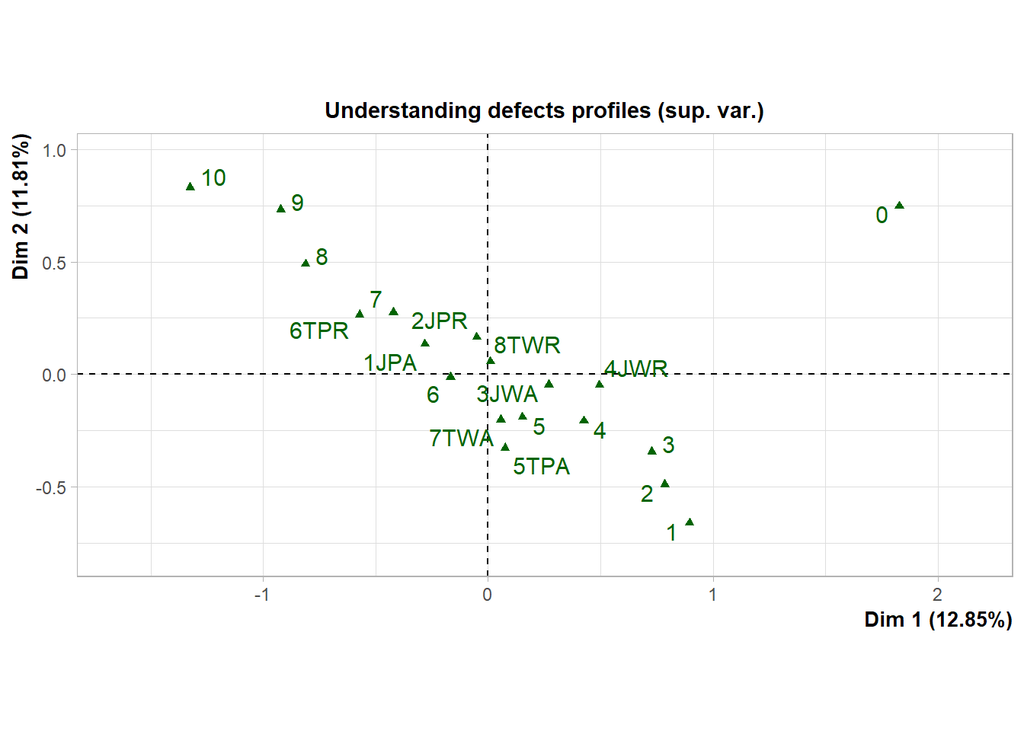

```r
orange$Liking.cat <- as.factor(orange$Liking)
res.mca <- MCA(orange[,-1], quanti.sup = 2, quali.sup = c(1,9), graph = F)
plot.MCA(res.mca, invisible = c("ind","var"), title = "Understanding defects profiles (sup. var.)")
```

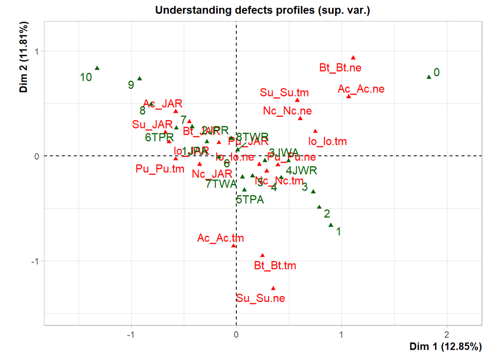

```r
plot.MCA(res.mca, invisible = "ind", title = "Understanding defects profiles (sup. var.)")
```

```r
names(res.mca)
```

```
## [1] "eig"        "call"       "ind"        "var"        "svd"
## [6] "quali.sup"  "quanti.sup"
```

```r
names(res.mca$var)
```

```
## [1] "coord"   "contrib" "cos2"    "v.test"  "eta2"
```

```r
res.mca$var$coord
```

```
##                Dim 1       Dim 2       Dim 3       Dim 4       Dim 5
## Nc_Nc.ne  0.60531329  0.35304562 -0.08284266 -1.19205974  0.54563268
## Nc_JAR   -0.35059049 -0.08242747 -0.43569956  0.25262652 -0.08087983
## Nc_Nc.tm  0.28675752 -0.14444346  1.19596166  0.55332029 -0.34201824
## Io_Io.ne  0.21666264 -0.08213262 -0.32006996 -0.14086362 -0.03656760
## Io_JAR   -0.64118626  0.13249261  0.49936849 -0.11616507 -0.45414403
## Io_Io.tm  0.74795994  0.23175480  0.98215701  1.99784980  2.49457769
## Su_Su.ne  0.34868459 -1.26580273 -0.34813591 -0.22143067 -0.12619355
## Su_JAR   -0.67589472  0.22384553 -0.08744302 -0.14472966  0.57741736
## Su_Su.tm  0.57662420  0.52656009  0.31989242  0.30816553 -0.59970297
## Ac_Ac.ne  1.06530715  0.56282995 -0.43781978  0.38786642 -0.29068617
## Ac_JAR   -0.57855830  0.42144444 -0.06755263 -0.16556207  0.19734014
## Ac_Ac.tm -0.02994674 -0.85888518  0.36632620 -0.06317738 -0.03759418
## Bt_Bt.ne  1.10875471  0.93139538 -0.33902181 -0.06180092  0.53961077
## Bt_JAR   -0.44845293  0.32516375  0.22267550 -0.12061185 -0.27872394
## Bt_Bt.tm  0.24610457 -0.95111040 -0.21638199  0.22648273  0.21952812
## Pu_Pu.ne  0.39334048 -0.08749062  0.49160302 -0.57880401  0.06337492
## Pu_JAR   -0.16843381  0.12548670 -0.76701639  0.46252185 -0.30657885
## Pu_Pu.tm -0.57889236 -0.02999111  0.28018825  0.46467257  0.41072052
```

```r
rownames(res.mca$var$coord)
```

```
##  [1] "Nc_Nc.ne" "Nc_JAR"   "Nc_Nc.tm" "Io_Io.ne" "Io_JAR"   "Io_Io.tm"
##  [7] "Su_Su.ne" "Su_JAR"   "Su_Su.tm" "Ac_Ac.ne" "Ac_JAR"   "Ac_Ac.tm"
## [13] "Bt_Bt.ne" "Bt_JAR"   "Bt_Bt.tm" "Pu_Pu.ne" "Pu_JAR"   "Pu_Pu.tm"
```

```r
mod.active <- rownames(res.mca$var$coord)

library(stringr)
str_detect(mod.active, "JAR")
```

```
##  [1] FALSE  TRUE FALSE FALSE  TRUE FALSE FALSE  TRUE FALSE FALSE  TRUE FALSE
## [13] FALSE  TRUE FALSE FALSE  TRUE FALSE
```

```r
which(str_detect(mod.active, "JAR"))
```

```
## [1]  2  5  8 11 14 17
```

```r
mod.active[which(str_detect(mod.active, "JAR"))]
```

```
## [1] "Nc_JAR" "Io_JAR" "Su_JAR" "Ac_JAR" "Bt_JAR" "Pu_JAR"
```

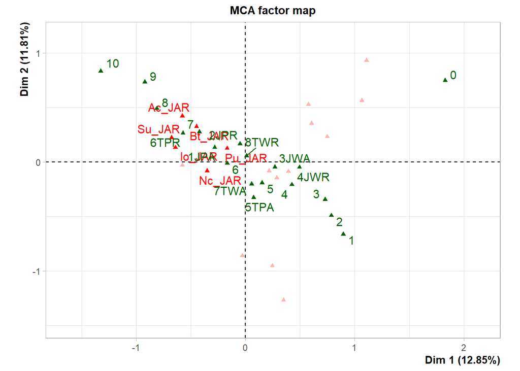

```r
mod <- "JAR"
mod.select <- mod.active[which(str_detect(mod.active, mod))]
plot.MCA(res.mca, invisible = "ind", selectMod = c(mod.select,rownames(res.mca$quali.sup$coord)))
```

L’ACM nous permet de visualisé en supplémentaire le liking et de voir qu’on a bien un gradient de liking. Deplus les just about right se trouve au niveau des 7, 8 ce à quoi on pouvait s’attendre.